# Using MCSim on Windows with RStudio

Nan-Hung Hsieh

2019/04/18 (update: 2019-05-29)

### 0. Background

GNU MCSim can run under different platforms (GNU/Linux, MacOS, and Windows). However, the basic tools in the Windows system are not available to build and run GNU MCSim. It needs a bit more extra steps to install and execute it. Therefore,

- Prof. Weihsueh Chiu proposed a practical method using **minGW** to install it (https://www.gnu.org/software/mcsim/mcsim_with_minGW.pdf).
- Dr. Frederic Bois also provide an alternative method to compile and run GNU MCSim through Rtools. This concept called “MCSim under R”.

Based on the second approach, I developed an R function named `mcsim_install()` in R package **pksensi** (https://cran.r-project.org/web/packages/pksensi/index.html) to help users easily install GNU MCSim through this function. Here, I proposed an additional idea to run GNU MCSim in RStudio, the integrated development environment (IDE) for R user. This project aim to help beginner write and run GNU MCSim’s model code in RStudio IDE.

### 1. Prerequisites

- R (https://cran.r-project.org/)
- RStudio (https://www.rstudio.com/)
- Rtools (https://cran.r-project.org/bin/windows/Rtools/)

The **R** is a programming language for statistical computing and graphics. The **RStudio** is an IDE for to edit and run R and GNU MCSim’s code. It can used to analyze and visualize the simulation result from GNU MCSim as well. The **Rtools** includes the C compiler that is used to compile the source code in GNU MCSim to the executable model program (mod.exe). **Rtools** and **Rstudio** can install through `install.Rtools()` and `install.rstudio()`in **installr** package.

### 2. Basic setting

The following steps can help you finish the basic setting to run GNU MCSim in RStudio,

- Download “MCSim_under_R” from GitHub repository (https://github.com/nanhung/MCSim_under_R) and unzip it. The `MCSim_under_R` folder include the latest version of GNU MCSim (v6.1.0) and some basic R functions (in `function.R`).

[figure not shown]

- Open `MCSim_under_R.Rproj` file in `MCSim_under_R`. It will open the Rstudio with the default working directory in `MCSim_under_R` folder. You can also run `getwd()` to make sure you are in the correct directory,

```r
getwd()
```

```
## [1] "/home/nanhung/mcsim_tutorial"
```

The `function.R` include some R functions to compile the source code to an executable program that will describe in the next section.

**Note:** The default PATH of Rtools is `"c:/Rtools/mingw_32/bin"`. If this is not the Rtools’ PATH in your computer, pleaase assign the PATH to set it. For example, `set_PATH(PATH = "c:/Useres/Rtools/mingw_32/bin")`.

### 3. Workflow

The workflow of MCSim under R can separate into three levels as following diagram,

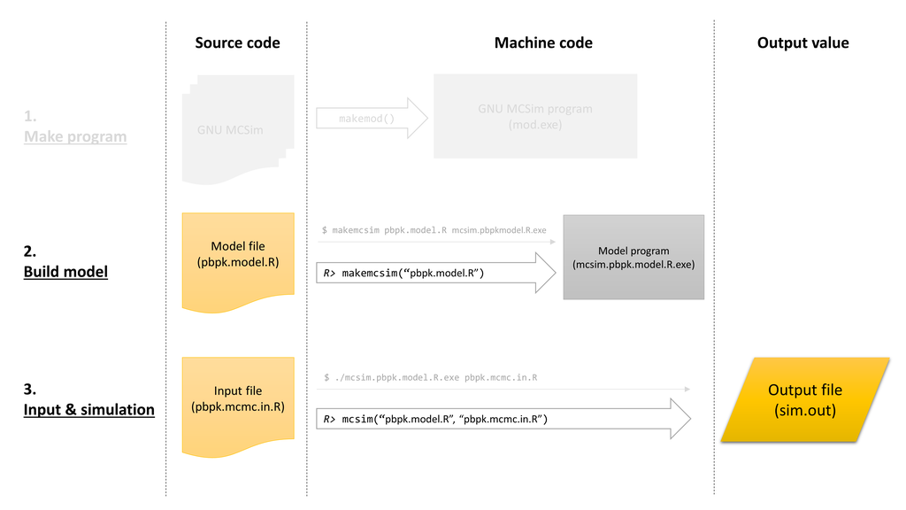

#### **3.1. Make program**

When loading the `function.R`, it will create the `mod.exe` program in MCSim folder through `makemod()`. Since MCSim is free and open source software, each file is provided through human-readable code (most are written by C language). To let the computer run these code, we need to compile the source code to the machine-readable program. The `makemod()` will automatically execute when loading the `function.R`, which means we don’t need to run this function unless we accidentally remove the `mod.exe`. Also, the **pkgbuild** package will be installed to check the Rtools.

#### **3.2. Build model**

Next, we need to build and compile the model code to the executable model program. We can use `makemcsim()` function to create the program with the name `mcsim. ... .exe`. The example code of linear model looks like this,

```r
# ---------------------------------------------------------
# Model definition file for a linear model (linear.model.R)
# ---------------------------------------------------------
Outputs = {y}

# Model Parameters
A = 0; # Default value of intercept
B = 1; # Default value of slope

# Statistical parameter
SD_true = 0;

CalcOutputs { y = A + B * t + NormalRandom(0,SD_true); }

End.
```

When building the model, be sure to put the semi-colon (;) at the end of statements. Also, the keyword “End.” should put at the end of every model. Then run the following code to create the model program `mcsim.linear.model.R.exe`.

```r
makemcsim(model = "linear.model.R")
```

```
## * Created executable program 'mcsim.linear.model.R.exe'.
```

The above function has the same action as `makemcsim linear.model.R mcsim.linear.model.R.exe` in command prompt.

#### **3.3. Input & simulation**

Finally, to conduct the model simulation, we need an input-file that includes the given model parameter value and/or input data based on the study purpose.

```r
# ---------------------------------------------------------
# Input definition file for a linear model (linear.in.R)
# ---------------------------------------------------------
Simulation { # 1 simple simulation

  A  = 1; # given value of intercept
  B  = 2; # given value of slope
  SD_true = 2; # given SD of noise

  PrintStep (y, 0, 10, 1);
}

END.
```

The `mcsim()` function in `function.R` provides an alternative way to run simulation in R environment instead of using the command prompt to run the simulation.

```r
out <- mcsim(model = "linear.model.R", input = "linear.in.R")
```

```
## Execute: ./mcsim.linear.model.R.exe modeling/linear.in.R
```

The simulation will generate an output file `sim.out`. The above function has the same action as `./mcsim.linear.model.R.exe linear.in.R` in command prompt.

The `mcsim()` can automatically read the output after generating the `sim.out`. Here is the output result,

```r
out
```

```
##    Time         y
## 1     0 -0.415609
## 2     1 -1.430340
## 3     2  4.144040
## 4     3  7.535080
## 5     4  9.517630
## 6     5 10.871900
## 7     6 13.735700
## 8     7 13.075000
## 9     8 16.095100
## 10    9 16.816300
## 11   10 21.300200
```

We can use the R base plot function to visualize the output as well.

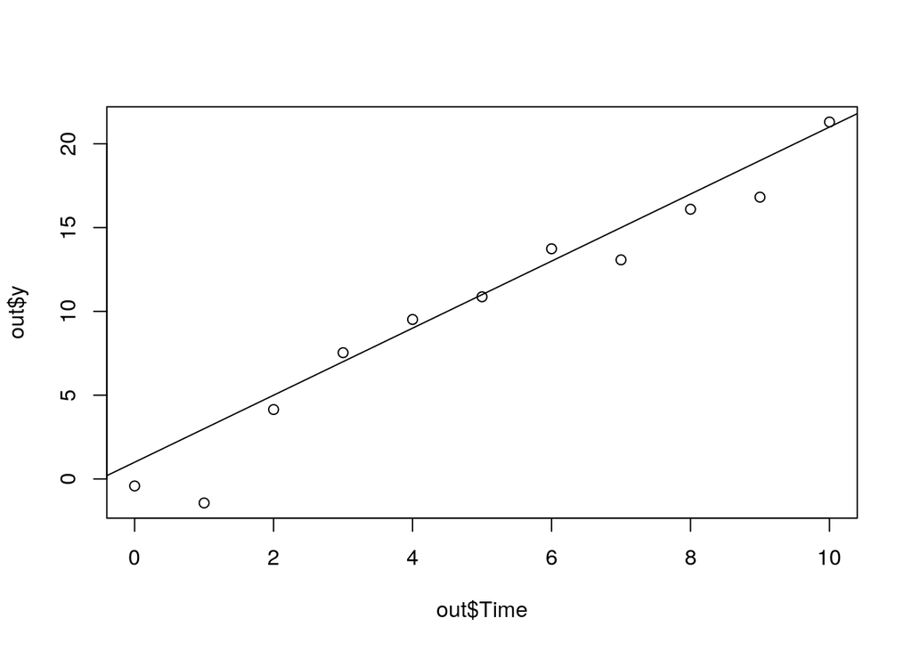

```r
plot(x = out$Time, y = out$y)
abline(a = 1, b = 2)
```

#### 3.4. Summary of R function (function.R)

Here are the R functions that can help you run GNU MCSim in R environment more easily. All R functions are put in `functions.R` in MCSim folder.

```r
set_PATH(PATH)
```

- Detecting, checking, and setting the C compiler in your computer. This process will automatically execute. The default PATH setting is `"c:/Rtools/mingw_32/bin"`. If your have “mingw_64” you can use `set_PATH(PATH = "c:/Rtools/mingw_64/bin")` to have faster compiling speed.

```r
makemod()
```

- Creating MCSim program `mod.exe`. This process will automatically execute.

```r
makemcsim(model, dir = "modeling", deSolve = F)
```

- Preprocessing and compiling the model-file to the executable file as `makemcsim` in GNU MCSim. The `model` assignment is a string giving the name of the model-file (e.g., `"linear.model.R"`). The *deSolve* assignment is a logical factor to use **deSolve** package as an ODE solver.
- The default location of modeling files are setting at `modeling` folder. The loaction can change by re-assign `dir`.

```r
mcsim(model, input, dir = "modeling", parallel = F)
```

- Using the compiled program with the input-file to run the simulation. The `input` assignment is a string giving the name of the input-file (e.g., `"linear.in.R"`). This function can also automatically compile the model, if you forgot to use `makemcsim()` to create model program. Besides, this function can also automatically compile the model.
- Can use `parallel = T` if using parallel computing in MCMC model calibration.

```r
clear()
```

- Removing all executable and output files with extension `.exe`, `.out`, and `.perks` in the working directory. This function is used to ensure that all simulation process can be reproduced without misusing the old version of the file with the same file name. This function will not remove `mod.exe`.

```r
mcsim_report()
```

- Reporting the system setting. If you meet any problem use this function and copy the report to https://github.com/nanhung/MCSim_under_R/issues

### 4. Additional examples

Some example R scripts will put into the `example` folder. Currently, it has a case of the linear model in `linear.R` that can be used to conduct the simple test run. To run GNU MCSim in model simulation, we need to have two types of file (1) **model** and (2) **input** files. The syntax of the model description file can find in GNU MCSim User’s Manual - Chapter 5.3. All example `model` and `input` files are located in the `modeling` folder.

Generally, the GNU MCSim used `.model` and `.in` as the extension to name the model- and input-file. However, RStudio doesn’t support the syntax highlight for these extensions. You can add `.R` as the extension for these files to help you edit your model or input in RStudio with syntax highlighting. Also, it can help you format your code in the code bracket.

### 5. Help

You are welcome to submit your problem to

- My GitHub repo (https://github.com/nanhung/MCSim_under_R/issues)
- GNU MCSim mailing list (https://lists.gnu.org/mailman/listinfo/help-mcsim).